# Abstract question 1

# Question 1: Where the STN’s paper came from

Where were the STN’s most important suppliers based and how far did the paper they used travel before arriving at their printing house in the Place Pury in Neuchâtel?

The first cell loads the necessary packages and the data for this notebook.

```r
library(tidyverse, quietly = T)
library(magrittr, quietly = T)
library(lubridate, quietly = T)
```

And this cell loads the data:

```r
papermakers <- read_csv("data/papermakers_with_places.csv")
papermakers
```

| client_code | client_name | has_correspondence | partnership | gender | data_source | option_menu_type | number_of_letters | number_of_documents | first_date | last_date | notes.x | place_code | address | ID | name | alternative_names | town | C18_lower_territory | C18_sovereign_territory | C21_admin | C21_country | geographic_zone | BSR | HRE | EL | IFC | P | HE | HT | … |
| --- | --- | --- | --- | --- | --- | --- | --- | --- | --- | --- | --- | --- | --- | --- | --- | --- | --- | --- | --- | --- | --- | --- | --- | --- | --- | --- | --- | --- | --- | --- |
| cl0011 | Fuzon ainé, Joseph | 0 | 0 | M | MS 1000A | Miscellaneous clients | 2 | 2 | 6th March 1776 | 30th March 1776 | NA | pl008 | NA | 11 | AMBERT | NA | AMBERT | Riom | France | Puy-de-Dôme | France | French | Bourbon France | 0 | 0 | 0 | 0 | 0 | 0 | … |
| cl0012 | Malmenayde & Fuzon | 0 | 0 | M | MS 1000A | Miscellaneous clients | 3 | 3 | 4th May 1773 | 28th December 1773 | NA | pl008 | NA | 12 | AMBERT | NA | AMBERT | Riom | France | Puy-de-Dôme | France | French | Bourbon France | 0 | 0 | 0 | 0 | 0 | 0 | … |
| cl0035 | Johannot, Matthieu & Fils | 0 | 0 | M | MS 1000A | Miscellaneous clients | 5 | 5 | 27th August 1770 | 13th February 1778 | MS1106 suggests that 'Mathieu' and 'Johannot' may be separate individuals. | pl015 | NA | 35 | ANNONAY | NA | ANNONAY | Montpellier | France | Ardèche | France | French | Bourbon France | 0 | 0 | 0 | 0 | 0 | 0 | … |
| cl0036 | Montgolfier, J. | 0 | 0 | M | MS 1000A | Miscellaneous clients | 1 | 1 | 3rd January 1775 | NA | NA | pl015 | NA | 36 | ANNONAY | NA | ANNONAY | Montpellier | France | Ardèche | France | French | Bourbon France | 0 | 0 | 0 | 0 | 0 | 0 | … |
| cl0041 | Sette, A. | 0 | 0 | M | MS 1000A | Miscellaneous clients | 7 | 7 | 20th December 1767 | 18th May 1783 | 'La convention' Sette-S.Fauche 05/06/1769 can be found in the dossier Fauche contre Heilmann. | pl019 | NA | 41 | ARDON | NA | ARDON | Besançon | France | Jura | France | French | Bourbon France | 0 | 0 | 0 | 0 | 0 | 0 | … |
| cl0078 | Blättler, Franz-Xaver | 0 | 0 | M | MS 1000A | Miscellaneous clients | 1 | 1 | 11th January 1778 | NA | NA | pl030 | NA | 79 | BÄCH | NA | BÄCH | Schwyz | Swiss confederation | Schwyz | Switzerland | Helvetic | Swiss | 0 | 0 | 0 | 0 | 0 | 0 | … |
| cl0082 | Blum, Jérome | 0 | 0 | M | MS 1000A | Miscellaneous clients | 21 | 21 | 22nd July 1769 | 13th July 1782 | NA | pl032 | NA | 83 | BALE | Basel, Basle | BASLE | Basle | Swiss confederation | Basel-Stadt | Switzerland | Helvetic | Swiss | 0 | 0 | 0 | 0 | 0 | 0 | … |
| cl0098 | Heusler, Nicolas | 0 | 0 | M | MS 1000A | Miscellaneous clients | 1 | 1 | 22nd July 1769 | NA | NA | pl032 | NA | 99 | BALE | Basel, Basle | BASLE | Basle | Swiss confederation | Basel-Stadt | Switzerland | Helvetic | Swiss | 0 | 0 | 0 | 0 | 0 | 0 | … |
| cl0128 | Stampfer & Heusler | 0 | 0 | M | MS 1000A | Miscellaneous clients | 2 | 2 | 22nd July 1769 | 29th July 1769 | NA | pl032 | NA | 129 | BALE | Basel, Basle | BASLE | Basle | Swiss confederation | Basel-Stadt | Switzerland | Helvetic | Swiss | 0 | 0 | 0 | 0 | 0 | 0 | … |
| cl0144 | Gurdat, Jean-Baptiste | 0 | 0 | M | MS 1000A | Miscellaneous clients | 40 | 40 | 10th August 1776 | 22nd July 1783 | NA | pl037 | NA | 144 | BASSECOURT | NA | BASSECOURT | Basle Bishopric | Basle Bishopric | Canton of Jura | Switzerland | Helvetic | Swiss | 0 | 0 | 0 | 0 | 0 | 0 | … |

[output cut: 56 more lines]

## Who were the most important suppliers?

The data does not tell us how much paper was actually supplied by the different papetiers. But we do know how many documents are in the STN archive from each supplier. We can use this to judge who the most important suppliers were.

First we can find the cutoff: what number of documents would put a supplier among the most important 25%

```r
third_quartile <- quantile(papermakers$number_of_documents, 0.75)
```

The third quartile is 21, so that 21 documents is a good cutoff to determine who was ‘important’. Though it must be noted that the top two papetiers both have more than 150 documents in the archive.

```r
papermakers %>%
  filter(number_of_documents > third_quartile) %>%
  arrange(desc(number_of_documents)) %>%
  select(client_name, number_of_letters, other_documents, name, distance_from_neuchatel) %T>%
  write_csv("most_important_papetiers.csv")
```

| client_name | number_of_letters | other_documents | name | distance_from_neuchatel |
| --- | --- | --- | --- | --- |
| Monnier | 200 | 0 | BESANCON | 74 |
| Charmet | 179 | 0 | BESANCON | 74 |
| Fontaine | 83 | 0 | FRIBOURG | 27 |
| Thomasset | 76 | 0 | VUILLAFANS | 55 |
| Cochet, Pierre | 43 | 3 | LYON | 211 |
| Gurdat, Jean-Baptiste | 40 | 0 | BASSECOURT | 45 |
| Ferreux & Caseau | 38 | 0 | BESANCON | 74 |
| Desgranges | 38 | 0 | LUXEUIL | 101 |
| Morel, Jean-Nicolas | 37 | 0 | MÉLIÈRE | 48 |
| Girard, Antoine | 34 | 2 | LYON | 211 |

[output cut: 6 more lines]

## How far did the paper have to come?

Another question is how far away the paper had to come before it arrived in the STN’s printing house.

If we assume that the amount of paper ordered is roughly in proportion to the number of letters in the archive, then we can take a weighted average:

```r
average_distance <- papermakers %>%
  mutate(intensity = number_of_documents/sum(number_of_documents)) %>%
  summarise(paper_distance = weighted.mean(distance_from_neuchatel, intensity))
```

According to this calculation, the paper had to come on average 97.96km before it arrived at the STN, at least as the crow flies. This makes sense if we look at the top four towns from which the paper came:

```r
papermakers %>%
  mutate(document_prop = number_of_documents/sum(number_of_documents)) %>%
  group_by(name, distance_from_neuchatel) %>%
  summarise(document_prop = sum(document_prop)) %>%
  arrange(desc(document_prop)) %>%
  ungroup() %>%
  mutate(total = cumsum(document_prop)) %T>%
  write_csv("data/top_two_thirds_places.csv")
```

| name | distance_from_neuchatel | document_prop | total |
| --- | --- | --- | --- |
| BESANCON | 74 | 0.3605150215 | 0.3605150 |
| LYON | 211 | 0.1459227468 | 0.5064378 |
| VUILLAFANS | 55 | 0.0961373391 | 0.6025751 |
| FRIBOURG | 27 | 0.0712446352 | 0.6738197 |
| BASSECOURT | 45 | 0.0360515021 | 0.7098712 |
| LUXEUIL | 101 | 0.0326180258 | 0.7424893 |
| MÉLIÈRE | 48 | 0.0317596567 | 0.7742489 |
| PONTARLIER | 45 | 0.0266094421 | 0.8008584 |
| STRASBOURG | 187 | 0.0248927039 | 0.8257511 |
| BALE | 81 | 0.0206008584 | 0.8463519 |

[output cut: 29 more lines]

As the table shows, the top four locations account for roughly 2/3 of the STN’s correspondence with papetiers. Three of the locations are less than 100 kilometres away as the crow flies, but the second most important location, Lyon, is 211km away.

## Did the intensity of correspondence decline with distance from neuchatel?

It would stand to reason if, overall, closer suppliers were preferred by the STN. And indeed it seems that this was so.

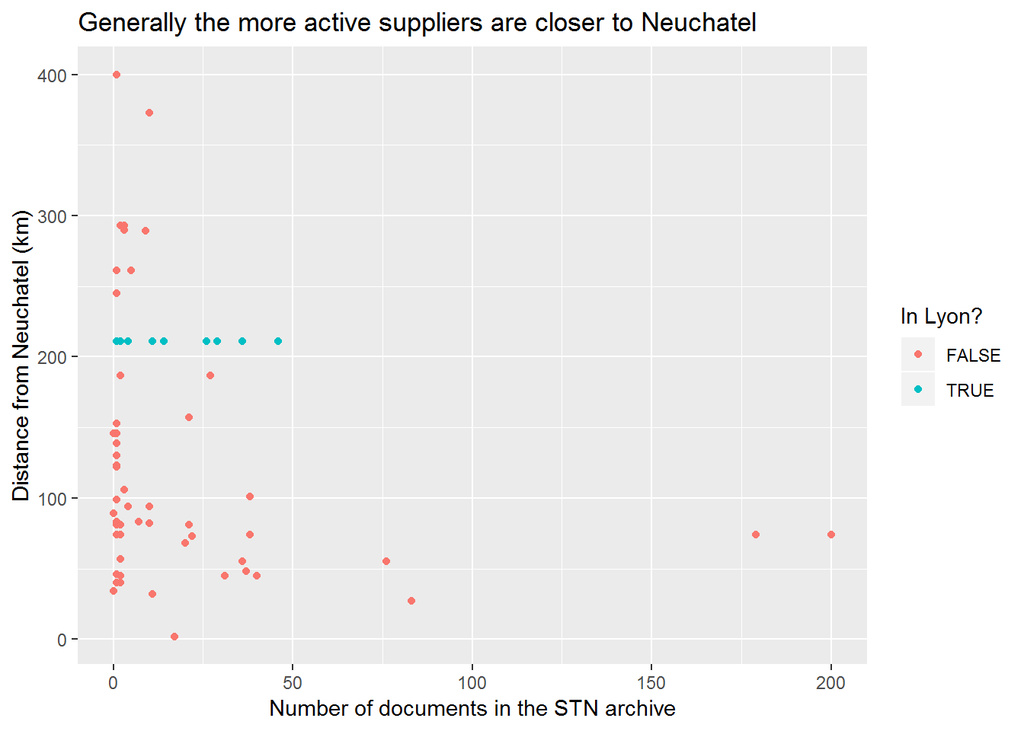

```r
papermakers %>%
  ggplot(aes(number_of_documents, distance_from_neuchatel, color = (in_lyon = name == "LYON"))) +
  geom_point() +
  labs(
    x = "Number of documents in the STN archive",
    y = "Distance from Neuchatel (km)",
    color = "In Lyon?",
    title = "Generally the more active suppliers are closer to Neuchatel"
  )
```

Statistical analysis suggests, however, that the correlation between distance and intensity of correspondence is not very strong:

```r
stats_results <- cor.test(papermakers$number_of_documents, papermakers$distance_from_neuchatel, alternative = "less", method = "spearman")
```

According to Spearman’s rank correlation coefficient, there is a relatively small correlation of -0.1661928 with a relatively high p-value of 0.0911583.

```r
filter(papermakers, name == "LYON") %>%
  select(client_name, name, number_of_documents, first_date, last_date)
```

| client_name | name | number_of_documents | first_date | last_date |
| --- | --- | --- | --- | --- |
| Bon | LYON | 1 | 28th August 1778 | NA |
| Brunet cadet & Cie | LYON | 14 | 29th February 1772 | 4th November 1774 |
| Charbonnet & Mouchard | LYON | 1 | 28th July 1778 | NA |
| Cochet, Pierre | LYON | 46 | 31st December 1770 | 19th April 1785 |
| Dumond | LYON | 11 | 7th December 1774 | 16th December 1777 |
| Girard, Antoine | LYON | 36 | 30th September 1775 | 14th October 1785 |
| Paullian, Pierre Marie | LYON | 2 | 29th May 1776 | 26th May 1777 |
| Schodelli, André & Cie | LYON | 29 | 6th November 1772 | 27th October 1778 |
| Tavernier | LYON | 26 | 17th December 1776 | 7th August 1781 |
| Villard | LYON | 4 | 11th February 1777 | 21st May 1777 |

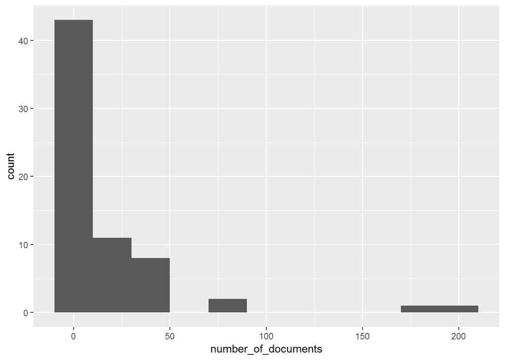

```r
papermakers %>%
  ggplot(aes(number_of_documents)) +
  geom_histogram(binwidth = 20)
```

## What about clients who were *only* papermakers?

```r
only_papermakers <- read_csv("data/papermakers_only_one_profession.csv")
only_papermakers %>%
  arrange(desc(number_of_documents))
```

| client_code | profession_code | client_name | has_correspondence | partnership | gender | data_source | option_menu_type | number_of_letters | number_of_documents | first_date | last_date | notes.x | place_code | address | ID | name | alternative_names | town | C18_lower_territory | C18_sovereign_territory | C21_admin | C21_country | geographic_zone | BSR | HRE | EL | IFC | P | HE | … |
| --- | --- | --- | --- | --- | --- | --- | --- | --- | --- | --- | --- | --- | --- | --- | --- | --- | --- | --- | --- | --- | --- | --- | --- | --- | --- | --- | --- | --- | --- | --- |
| cl0291 | pf171 | Monnier | 0 | 0 | M | MS 1000A | Miscellaneous clients | 200 | 200 | 20th October 1770 | 30th November 1787 | NA | pl052 | NA | 291 | BESANCON | NA | BESANÇON | Besançon | France | Doubs | France | French | Bourbon France | 0 | 0 | 0 | 0 | 0 | … |
| cl0638 | pf171 | Fontaine | 0 | 0 | M | MS 1000A | Miscellaneous clients | 83 | 83 | 14th December 1777 | 2nd June 1787 | NA | pl165 | NA | 638 | FRIBOURG | Freiberg | FREIBERG | Fribourg | Swiss confederation | Fribourg | Switzerland | Helvetic | Swiss | 0 | 0 | 0 | 0 | 0 | … |
| cl1517 | pf171 | Thomasset | 0 | 0 | M | MS 1000A | Miscellaneous clients | 76 | 76 | 12th January 1771 | 13th May 1784 | NA | pl433 | NA | 1503 | VUILLAFANS | NA | VUILLAFANS | Besançon | France | Doubs | France | French | Bourbon France | 0 | 0 | 0 | 0 | 0 | … |
| cl1102 | pf171 | Cochet, Pierre | 0 | 0 | M | MS 1000A | Miscellaneous clients | 43 | 46 | 31st December 1770 | 19th April 1785 | Additional documents - 3 'lettres de voiture'. | pl233 | NA | 1094 | LYON | Lyons | LYONS | Lyon | France | Rhône | France | French | Bourbon France | 0 | 0 | 0 | 0 | 0 | … |
| cl0284 | pf171 | Ferreux & Caseau | 0 | 0 | M | MS 1000A | Miscellaneous clients | 38 | 38 | 15th April 1778 | 27th December 1782 | NA | pl052 | NA | 284 | BESANCON | NA | BESANÇON | Besançon | France | Doubs | France | French | Bourbon France | 0 | 0 | 0 | 0 | 0 | … |
| cl1070 | pf171 | Desgranges | 0 | 0 | M | MS 1000A | Miscellaneous clients | 38 | 38 | 22nd August 1778 | 14th August 1783 | From 29/09/1781 see Desgranges père et fils cadet. | pl232 | NA | 1062 | LUXEUIL | Luxeuil-les-Bains | LUXEUIL | Besançon | France | Haute-Saône | France | French | Bourbon France | 0 | 0 | 0 | 0 | 0 | … |
| cl1220 | pf171 | Morel, Jean-Nicolas | 0 | 0 | M | MS 1000A | Miscellaneous clients | 37 | 37 | 16th March 1777 | 14th March 1783 | NA | pl250 | NA | 1210 | MÉLIÈRE | Meslière, Merslières | MÉLIÈRE | Besançon | France | Doubs | France | French | Bourbon France | 0 | 0 | 0 | 0 | 0 | … |
| cl1118 | pf171 | Girard, Antoine | 0 | 0 | M | MS 1000A | Miscellaneous clients | 34 | 36 | 30th September 1775 | 14th October 1785 | Additional documents - 2 printed 'adresses'. | pl233 | au coin de la rue Neuve | 1111 | LYON | Lyons | LYONS | Lyon | France | Rhône | France | French | Bourbon France | 0 | 0 | 0 | 0 | 0 | … |
| cl1516 | pf171 | Planche | 0 | 0 | M | MS 1000A | Miscellaneous clients | 36 | 36 | 29th April 1770 | 3rd June 1783 | NA | pl433 | NA | 1502 | VUILLAFANS | NA | VUILLAFANS | Besançon | France | Doubs | France | French | Bourbon France | 0 | 0 | 0 | 0 | 0 | … |
| cl1792 | pf171 | Verchet, Jacques | 0 | 0 | M | MS 1000A | Miscellaneous clients | 31 | 31 | 12th February 1770 | 2nd September 1773 | NA | pl321 | NA | 1779 | PONTARLIER | NA | PONTARLIER | Besançon | France | Doubs | France | French | Bourbon France | 0 | 0 | 0 | 0 | 0 | … |

[output cut: 48 more lines]

That knocks out eight clients. Now how does the `documents`/`distance` curve look?

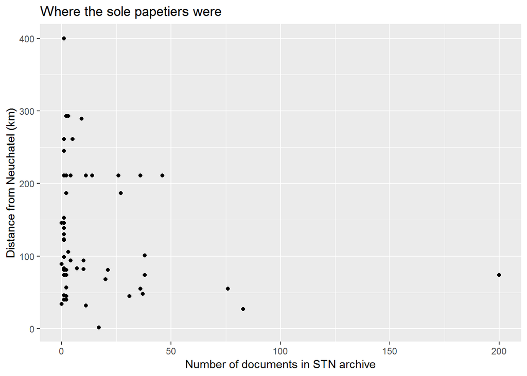

```r
only_papermakers %>%
  ggplot(aes(number_of_documents, distance_from_neuchatel)) +
  geom_point() +
  labs(
    x = "Number of documents in STN archive",
    y = "Distance from Neuchatel (km)",
    title = "Where the sole papetiers were"
  )
```

```r
stats2 <- cor.test(only_papermakers$number_of_documents, only_papermakers$distance_from_neuchatel, alternative = "less", method = "spearman")
```

Knocking out the papetiers with other professions does not seem to have changed the graph. Excluding these others has not altered the distribution of the data statisically. Spearman’s rho is -0.1733163, with a p-value of 0.0966163.

## Questions

The most obvious question that arises from this first analysis is: what was so special about Besancon and Lyon? Was Lyon’s highly developed textiles industry a good source of rags, the raw material of eighteenth-century paper? Could we perhaps correlate these patterns with the population size of different centres? Is our current measurement of ‘distance from Neuchatel’, kilometres as the crow flies, a useful metric at all? Can we find out how far these places were from one another in eighteenth-century transport?